# lab3_421_template

October 11, 2019

QUIZ/LAB 3 (The actual questions are in *italic*)

In this lab we are going to play with 1-way ANOVA. First, we get practice in using **lm()** for doing it, then we will look at effects, and finally we will “prove,” via simulation, a result from Wednesday’s lecture: $E[MSTr] = \sigma^2 + (n/(a-1)) * \sum( (\tau_i)^2 )$ .

1. *Write code to take a=4 samples of size n=100 from a normal dist with sigma = 1, but with mu1 = 0, mu2 = 0.5, mu3 = 1.0, and mu4 = 0.5; and then, do 1-way ANOVA on the resulting data. The answer here will be the ANOVA table showing all the SS values, the F ratio, and the corresponding p-value. Use lm(), i.e., DO NOT use the basic formulas we have derived for the different SS’s.* *Start your code with set.seed(123)*

```r
# write your code here
set.seed(123)
a = 4
n = 100
y_m <- matrix(nrow=a, ncol=n)
y_m[1,] = rnorm(100, 0, 1)
y_m[2,] = rnorm(100, 0.5, 1)
y_m[3,] = rnorm(100, 1, 1)
y_m[4,] = rnorm(100, 0.5, 1)

A <- as.factor(rep(c(1, 2, 3, 4), each=n))
y <- as.vector(y_m)
pool_dt <- data.frame(A, y)

lm_1 <- lm(y~A)
summary.aov(lm_1) # F-statistics is 0.738
```

```
##              Df Sum Sq Mean Sq F value Pr(>F)
## A             3    2.4  0.7931   0.738   0.53
## Residuals   396  425.3  1.0739
```

```r
aov(y~A) # SStr = 2.3792, SSe = 425.2842
```

```
## Call:
##    aov(formula = y ~ A)
##
## Terms:
##                        A Residuals
## Sum of Squares    2.3792  425.2842
## Deg. of Freedom        3       396
##
## Residual standard error: 1.036316
## Estimated effects may be unbalanced
```

Let’s also check the effects, i.e., tau_i. Let y denote the (n x a) data matrix. Then, our estimate of tau_i is given by (yi._bar - y.._bar ). Call them tau_i_hat. That’s just a=4 numbers.

tau_i_hat = apply(y,2,mean) - mean(y) # -0.42636942 -0.12432213 0.60368978 -0.05299824

But we can also do something more useful: Make an (n x a) matrix such that its column means are those 4 numbers. To that end,

```r
# space to experiment
y_new = t(y_m)
tau_i_hat = apply(y_new,2,mean) - mean(y_new)
```

2. *Write code to subtract the row mean from every of row of y. Call the resulting matrix tau_i . Hint: if/when you have done it correctly, the 100 row means (i.e., apply(tau_i, 1, mean) ) will be nearly zero; and the column means will be the 4 numbers you saw, above, for the effect.*

```r
# write your code here
y_new = t(y_m)
row_mean = apply(y_new, 1, mean)
tau_i = y_new - row_mean
```

3. *Write code to perform t-tests on each of the 4 columns of tau_i to test whether the true mean of each column is zero. Report the p-values.*

```r
# write your code here
p_values = numeric(a)
for (i in 1:a) {
  p_values[i] = t.test(tau_i[,i])$p.value
}
p_values
```

```
## [1] 2.529665e-06 1.309851e-01 2.177967e-10 5.482009e-01
```

4. *At* $\alpha = 0.05$*, are the results of the 4 tests in part c consistent with that of the ANOVA F-test? Explain.*

Base on the one-way F-test, the p-value of onserved F-statistics is 0.53, which, under alpha level of 0.05, is not a strong evidence against H0. This implies F-test fail to provide evidence that difference in means exist. However, in part c, the p-value of level 1 and level 3 are smaller than alpha, providing the evidence that their mean is non-zero, while the test fail to provide evidence saying that mean of level 2 and 4 are non-zero. Therefore, based on part c, it is plausible that means are different.

5. *Write code to make the sampling distribution of MSTr across 10,000 trials. This time, DO NOT use lm(); instead, use the defining formula for MSTr. Also, use only one set.seed(123) at the start of your code.*

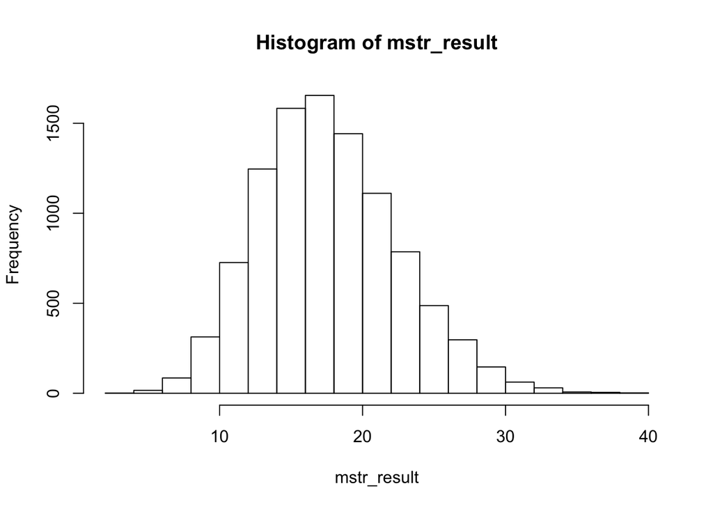

```r
# write your code here
set.seed(123)
ntrial = 10000
mstr_result = numeric(ntrial)
a = 4
n = 100

for (i in 1:ntrial) {
  y_m <- matrix(nrow=a, ncol=n)
  y_m[1,] = rnorm(100, 0, 1)
  y_m[2,] = rnorm(100, 0.5, 1)
  y_m[3,] = rnorm(100, 1, 1)
  y_m[4,] = rnorm(100, 0.5, 1)
  grand_mean <- mean(as.vector(y_m))
  row_mean <- apply(y_m, 1, mean)
  sp_mstr <- 1/(a-1) * n * sum((row_mean - grand_mean)^2)
  mstr_result[i] = sp_mstr
}
hist(mstr_result)
```

6. *Compute the mean (across the 10,000 trials) of MSTr, and show that it is approx. equal to* *( sigma^2 + (n/(a-1)) times sum( (tau_i)^2) ), where tau_i = mean(mu_i) - mu_i .*

```r
# write your code here

mean(mstr_result)
```

```
## [1] 17.6182
```

```r
mu_i <- c(0, 0.5, 1, 0.5)

tau_i <- mean(mu_i) - mu_i

difference <- mean(mstr_result) - (1^2 + (n/(a-1)) * sum((tau_i)^2 ))
difference
```

```
## [1] -0.04847001
```

```r
# Yes, these two values are very close
```